# Predictive Model for Customer Churn: A Case Study in Banking

## Objective

To develop a model/method for identifying customers who are likely to exit

## Background:

Bank customer churn, also known as customer attrition, refers to the phenomenon where customers stop doing business with a bank or switch to another bank. Churn is a critical metric for banks as it directly impacts their customer base and revenue. The dataset represents bank customer information for churn analysis. Each row in the dataset corresponds to a specific customer and contains several features or attributes that describe them.

### Import Libraries

```python
import pandas as pd
import numpy as np
import seaborn as sns
import matplotlib.pyplot as plt
from sklearn.metrics import classification_report
from sklearn.preprocessing import StandardScaler
#BLR
from sklearn.model_selection import train_test_split
from sklearn.linear_model import LogisticRegression
#NB
from sklearn.naive_bayes import GaussianNB
from sklearn.metrics import roc_curve, roc_auc_score
#svm
from sklearn.svm import SVC
import warnings
warnings.filterwarnings("ignore", category=FutureWarning)
```

## Import Data

```python
data = pd.read_csv('Bank Churn.csv')
data.head()
```

|  | RowNumber | CustomerId | Surname | CreditScore | Geography | Gender | Age | Tenure | Balance | NumOfProducts | HasCrCard | IsActiveMember | EstimatedSalary | Exited |
| --- | --- | --- | --- | --- | --- | --- | --- | --- | --- | --- | --- | --- | --- | --- |
| 0 | 1 | 15634602 | Hargrave | 619 | France | Female | 42 | 2 | 0.00 | 1 | 1 | 1 | 101348.88 | 1 |
| 1 | 2 | 15647311 | Hill | 608 | Spain | Female | 41 | 1 | 83807.86 | 1 | 0 | 1 | 112542.58 | 0 |
| 2 | 3 | 15619304 | Onio | 502 | France | Female | 42 | 8 | 159660.80 | 3 | 1 | 0 | 113931.57 | 1 |
| 3 | 4 | 15701354 | Boni | 699 | France | Female | 39 | 1 | 0.00 | 2 | 0 | 0 | 93826.63 | 0 |
| 4 | 5 | 15737888 | Mitchell | 850 | Spain | Female | 43 | 2 | 125510.82 | 1 | 1 | 1 | 79084.10 | 0 |

### Data Description

```python
#Data description
```

### Converting data types (Required for modelling)

```python
#Converting datatype
data[['HasCrCard', 'IsActiveMember','Geography','Gender']] = data[['HasCrCard', 'IsActiveMember','Geography','Gender']].astype('category')
data.info()
```

```
<class 'pandas.core.frame.DataFrame'>
RangeIndex: 10000 entries, 0 to 9999
Data columns (total 14 columns):
 #   Column           Non-Null Count  Dtype
---  ------           --------------  -----
 0   RowNumber        10000 non-null  int64
 1   CustomerId       10000 non-null  int64
 2   Surname          10000 non-null  object
 3   CreditScore      10000 non-null  int64
 4   Geography        10000 non-null  category
 5   Gender           10000 non-null  category
 6   Age              10000 non-null  int64
 7   Tenure           10000 non-null  int64
 8   Balance          10000 non-null  float64
 9   NumOfProducts    10000 non-null  int64
 10  HasCrCard        10000 non-null  category
 11  IsActiveMember   10000 non-null  category
 12  EstimatedSalary  10000 non-null  float64
 13  Exited           10000 non-null  int64
dtypes: category(4), float64(2), int64(7), object(1)
memory usage: 820.9+ KB
```

### Splitting Data into Train and Test data sets

```python
# Define the features and target variable
x_variables = ['CreditScore', 'Geography', 'Gender', 'Age', 'Tenure', 'Balance',
               'NumOfProducts', 'HasCrCard', 'IsActiveMember', 'EstimatedSalary']
X = data[x_variables]
y = data['Exited']

# Convert categorical variables into dummy variables
X_encoded = pd.get_dummies(X, columns=['Geography', 'Gender', 'HasCrCard', 'IsActiveMember'], drop_first=True)

# Split the data into training and testing sets
X_train, X_test, y_train, y_test = train_test_split(X_encoded, y, test_size=0.2, random_state=42)
```

### Note :

When you are using LogisticRegression from scikit, it is recommended to standardize X variables to avoid the problem of non-convergence (which is not required while using logit())

```python
scaler = StandardScaler()
scaler.fit(X_train)

X_train = scaler.transform(X_train)
X_test = scaler.transform(X_test)
```

### Setting the threshold

```python
counts = data['Exited'].value_counts().reset_index()
counts.columns = ['Exited', 'Freq']
counts['Percent'] = counts['Freq'] / counts['Freq'].sum()

print(counts)
```

```
   Exited  Freq  Percent
0       0  7963   0.7963
1       1  2037   0.2037
```

```python
threshold = 0.2 #One can try out different thresholds
```

## Model 1. Binary Logistic Regression

### Building Model

```python
# Initialize the logistic regression model
logreg =LogisticRegression(max_iter=1000)

# Fit the model on the training data
logreg.fit(X_train, y_train)
```

```
LogisticRegression(max_iter=1000)
```

### Note :

The logit() in statsmodels library provides table of coefficients, standard error and p values for hypothesis testing. However, the LogisticRegression() in sklearn follows ML approach with focus on predictions.

```python
# Predict the class labels
y_pred = logreg.predict(X_test)
```

```python
predprob_test = logreg.predict_proba(X_test)
pred_test = np.where(predprob_test[:,1] > threshold, 1, 0)
```

### Generate classification report

```python
print(classification_report(y_test,pred_test))
```

```
              precision    recall  f1-score   support

           0       0.91      0.70      0.79      1607
           1       0.37      0.72      0.49       393

    accuracy                           0.70      2000
   macro avg       0.64      0.71      0.64      2000
weighted avg       0.80      0.70      0.73      2000
```

### Computing AUC value for ROC curve

```python
auc = roc_auc_score(y_test, predprob_test[:,1])
print('AUC: %.3f' % auc)
```

```
AUC: 0.779
```

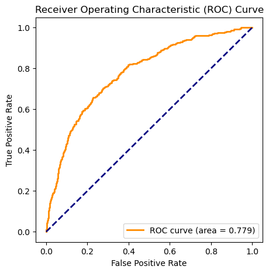

```python
# Plot ROC Curve for Test data
fpr, tpr, _ = roc_curve(y_test, predprob_test[:,1])
plt.figure(figsize=(5, 5))
lw=2
plt.plot(fpr, tpr, color='darkorange',lw=lw, label='ROC curve (area = %0.3f)' % auc)
plt.plot([0, 1], [0, 1], color='navy', lw=lw, linestyle='--')
plt.title('Receiver Operating Characteristic (ROC) Curve')
plt.xlabel('False Positive Rate')
plt.ylabel('True Positive Rate')
plt.legend(loc='lower right')
plt.show()
```

### The overall model accuracy is 70%. The area under ROC curve is 77

## Model 2. Naive Bayes

The scikit-learn library has two functions for Naive Bayes method:

1. GaussianNB() for numeric predictors
2. MultinomialNB() for categorical predictors

Here, we use GaussianNB() by converting categorical variables into numeric variables(dummy variables). This is a general industry practice. However one can convert numeric variable into categorical variable using MultinomialNB()

### Building Model

```python
# Create and fit the Gaussian Naive Bayes modelx
NBmodel = GaussianNB()

NBmodel.fit(X_train, y_train)
```

```
GaussianNB()
```

### Predicting probabilities

```python
# Make predictions on the test set
y_pred = NBmodel.predict(X_test)
```

```python
predprob_test = NBmodel.predict_proba(X_test)
pred_test = np.where(predprob_test[:,1] > threshold, 1, 0)
```

### Generating Classification Report

```python
print(classification_report(y_test,pred_test))
```

```
              precision    recall  f1-score   support

           0       0.92      0.73      0.81      1607
           1       0.40      0.73      0.51       393

    accuracy                           0.73      2000
   macro avg       0.66      0.73      0.66      2000
weighted avg       0.81      0.73      0.75      2000
```

### Computing AUC value for ROC curve

```python
auc = roc_auc_score(y_test, predprob_test[:,1])
print('AUC: %.3f' % auc)
```

```
AUC: 0.804
```

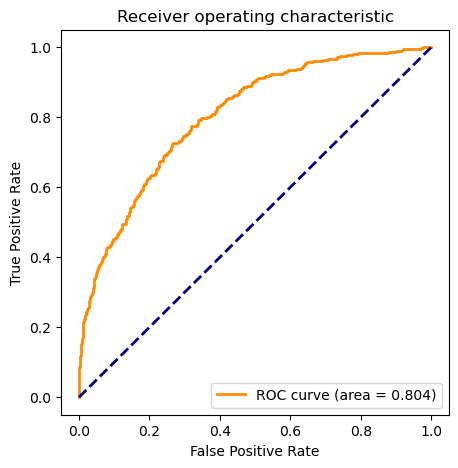

```python
NBfpr, NBtpr, thresholds = roc_curve(y_test, predprob_test[:,1])

# plot the roc curve for Test data
plt.figure(figsize=(5, 5))
lw = 2
plt.plot(NBfpr, NBtpr, color='darkorange',lw=lw, label='ROC curve (area = %0.3f)' % auc)
plt.plot([0, 1], [0, 1], color='navy', lw=lw, linestyle='--')
plt.axis('tight')
plt.xlabel('False Positive Rate');plt.ylabel('True Positive Rate')
plt.title('Receiver operating characteristic')
plt.legend(loc="lower right")
plt.show()
```

### The overall model accuracy is 73%. The area under ROC curve is 80

## Model 3. Support Vector Machine (SVM)

### Building Model

```python
svm_model = SVC(probability=True, random_state=0,kernel = 'linear')
```

```python
svm_model.fit(X_train, y_train)
```

```
SVC(kernel='linear', probability=True, random_state=0)
```

### Predicting probabilities

```python
predprob_test = svm_model.predict_proba(X_test)
pred_test = np.where(predprob_test[:,1] > threshold, 1, 0)
```

### Generate Classification Report

```python
print(classification_report(y_test,pred_test))
```

```
              precision    recall  f1-score   support

           0       0.90      0.48      0.63      1607
           1       0.27      0.77      0.40       393

    accuracy                           0.54      2000
   macro avg       0.58      0.63      0.51      2000
weighted avg       0.77      0.54      0.58      2000
```

### Computing AUC value for ROC curve

```python
# Calculate AUC
roc_auc = roc_auc_score(y_test,predprob_test[:,1])
print(f"AUC: {roc_auc:.5f}")
```

```
AUC: 0.67779
```

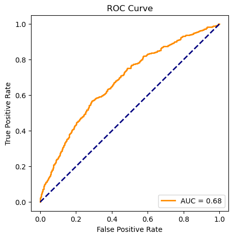

```python
# Plot ROC curve for test data
fpr, tpr, thresholds = roc_curve(y_test, predprob_test[:,1])
plt.figure(figsize=(5,5))
plt.plot(fpr, tpr, color='darkorange', lw=2, label=f'AUC = {roc_auc:.2f}')
plt.plot([0, 1], [0, 1], color='navy', lw=2, linestyle='--')
plt.xlabel('False Positive Rate')
plt.ylabel('True Positive Rate')
plt.title('ROC Curve')
plt.legend(loc='lower right')
plt.show()
```

### The overall model accuracy is 54%. The area under ROC curve is 68